# The Impact of Connection on United States Politics

Author

Sophia LaRocca

Published

August 15, 2025

```r
library(tidyverse)
library(readr)
library(dplyr)
library(tidyr)
library(stringr)
library(lubridate)
library(here)
library(forcats)
library(stringr)
library(ggplot2)
```

# Introduction

Different people can believe different things; a fact of life. Our beliefs, who we are, what we do, is impacted daily. They are shaped by who we are, how we’re raised, the communities we are a part of, and changes in the world around us. It is possible to notice patterns in beliefs and ideologies when you look at the groups people are a part of, it’s hard to point out one part of ones life and say “this right here is what made me think a certain way”.

Professor Michael J. Nelson and Ph.D. Candidate Morrgan T. Herlihy worked together to figure out what determines public support within the United States for specific judicial candidates in their article, “Judging Judicial Nominees”. Collecting responses from a nationally representative sample, this duo showed their respondents judicial nominees who were considered “Forthcoming”, “Client”, or “Avoidant” to the issue of abortion and asked the respondents whether or not they would support the nominee. To insure that their audience had the full picture as to who they were surveying, the pair collected information on their respondents Gender, Age, Political Party, Ideology, Opinion on the matter of Abortion, Religious belief, and more, publishing their findings June 12, 2025.

It is through analysis of this data, that I endeavor to answer the following questions about the United States Populace and how connections to different groups might impact ones politics:

**Question 1**: Are women inherently more pro-choice than men?

**Question 2**: How does age correspond with political ideology?

**Question 3**: Does religion impact political ideology?

# The Dataset

Before I can properly analyze the data from “Judging Judicial Nominees”, I need to reorganize it and change the values of certain columns so I can more easily work with it. I rearranged the data so it was organized by gender and age, going through each gender from youngest to oldest.

```r
#First I'm reading in respondent data
respondent_data <- read.csv("data/respondent_level_vignette_5_29_25.csv")

#Now I'm going to rearrange it. I think the best arrangement of the data
#is by age and gender.
respondent_data<- arrange(respondent_data,`Age`)
respondent_data <-arrange(respondent_data,`Female`)

#After this I'm mutating the data so the numerical sections that
#represent different responses actually give those different responses
respondent_data <- respondent_data|>
  mutate(Prochoice_Op=case_when(
    Prochoice_Op==1~"Strongly Pro-Choice",
    Prochoice_Op==2~"Pro-Choice",
    Prochoice_Op==3~"Neutral",
    Prochoice_Op==4~"Pro-Life",
    Prochoice_Op==5~"Strongly Pro-Life"),Ideology=case_when(
      Ideology==0|is.na(Ideology)==T~"Unknown",
      Ideology==1~"Liberal",
      Ideology==2~"Moderate",
      Ideology==3~"Conservative",
      Ideology==4~"Very Conservative"))

#Finally, I'm getting rid of Nom_SupportDV and Treatment columns as
#neither are relevant to the research questions I'm exploring
respondent_data<-relocate(respondent_data,`Nom_SupportDV`,
                          .after=`Religious`)
respondent_data<-relocate(respondent_data,`Treatment`,.after=`Religious`)
respondent_data<-select(respondent_data,1:9)

#I'm writing the cleaned up data into a new CSV file that I intend to
#submit alongside the original csv file to show the changes I've made
#between the two
write_csv(respondent_data, "data/respondent_data.csv")
```

Now that the data has been sufficiently tidied, I can begin to consider the research questions.

# Question 1: Are women inherently more Pro-Choice than men?

When it comes to politics within the United States, especially during the current political climate after the overturning of Roe v. Wade, abortion is a topic of debate among many.

Of the 1500 respondents in this data, 794 of them are Female and 706 of them are Male. This amounts to roughly 53% of the respondents being Female and the other 47%, Male, an almost even split between the two genders, shown visually by the bar graph “Gender Distribution”.

```r
#Making a table to show the ratio of Males to Females
respondent_data %>% count("Gender"=`Female`)
```

| Gender | n |
| --- | --- |
| Female | 794 |
| Male | 706 |

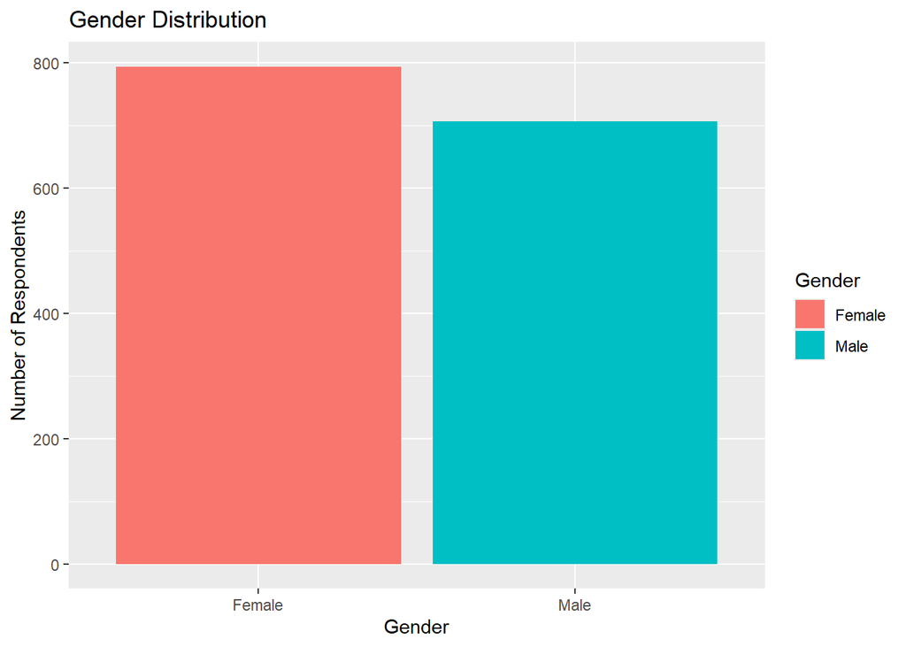

```r
#Making a chart to show the ratio as well. Both is good.
ggplot(respondent_data,aes(`Female`,fill=`Female`))+geom_bar()+labs(
                                              title="Gender Distribution",
                                              x="Gender",
                                              y="Number of Respondents",
                                              alt="The distribution of
                                              gender among those who
                                              responded to the
                                            survey")+scale_fill_discrete(
                                              name="Gender")
```

But what is the distribution of Pro-Choice and Pro-Life opinions amongst these groups? Comparing the two using the “Pro-Choice v Pro-Life by Gender” bar chart, I found that the ratios of the different abortion opinions remained rather consistent between the two genders. 277 Females had a “Neutral” stance and 263 Males shared their view, while 236 Females and 261 Males were “Pro-Choice”, 213 Females and 131 Males were “Pro-Life”, and 68 Females and 50 Males were “Strongly Pro-Choice”.

This means, of the Female respondents, 35% had a “Neutral” Stance, 30% were “Pro-Choice”, 27% were “Pro-Life”, and 8% were “Strongly Pro-Choice”. Of the Male Respondents, 37% adopted a “Neutral” Stance, 37% were “Pro-Choice”, 19% were “Pro-Life”, and 7% were “Strongly Pro-Choice”.

The “Neutral” and “Strongly Pro-Choice” stances mirrored each other between the genders, however, the differences in the “Pro-Life” and “Pro-Choice”, a total of 8% towards the “Pro-Choice” side for the Males and “Pro-Life” side for the Females, leads to the conclusion that women are not inherently more Pro-Choice than men within the United States.

```r
#separating out the female respondents to get the count of their
#abortion opinions
female_respondents<-filter(respondent_data,`Female`=="Female")

female_respondents %>% count("Female Abortion Opinions"=`Prochoice_Op`)
```

| Female Abortion Opinions | n |
| --- | --- |
| Neutral | 277 |
| Pro-Choice | 236 |
| Pro-Life | 213 |
| Strongly Pro-Choice | 68 |

```r
#separating out the male respondents to get the count of their
#abortion opinions
male_respondents<-filter(respondent_data,`Female`=="Male")

male_respondents %>% count("Male Abortion Opinions"=`Prochoice_Op`)
```

| Male Abortion Opinions | n |
| --- | --- |
| Neutral | 263 |
| Pro-Choice | 261 |
| Pro-Life | 131 |
| Strongly Pro-Choice | 50 |
| NA | 1 |

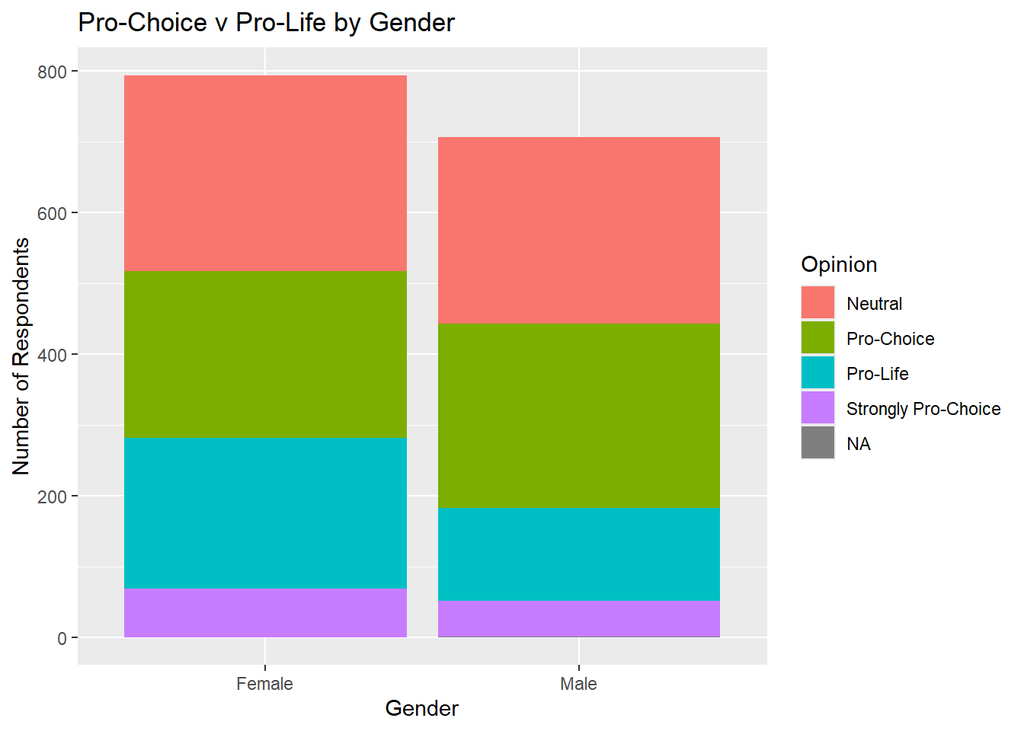

```r
#using a bar graph to compare the stats as necessary
ggplot(respondent_data,aes(`Female`,
                                  fill=`Prochoice_Op`))+geom_bar()+labs(
                                title="Pro-Choice v Pro-Life by Gender",
                                x="Gender",
                                y="Number of Respondents",
                                alt="Gender & Opinions on Pro-Choice vs
                                Pro-Life")+scale_fill_discrete(
                                name="Opinion")
```

# Question 2: How does age correspond with political ideology?

As a nation changes, so do its people and its politics. Growing up in different decades with differing ideologies means that people are liable to find their opinions differing from those of people in other generations.

To determine just how much age corresponds with political ideology, I first look to determine the distribution of the ages within this dataset. The minimum age of any respondent was 18 while the maximum age was 94 a range of ages that spreads across multiple generations. One can assume that there are adults in various stages of life within the data as there are 77 unique ages within the data set, meaning age within the range is represented by at least one person. With a mean of ~49 and a median of 49 as well, the graph is slighty right skewed.

```r
#creating a function to go through all the columns a user wants
#and get information such as the min, max, mean, median, and
#standard deviation
numbers_stuff <- function(input_data_frame,column_names){
  #first select the columns the user intends to analyze
  input_data_frame <- select(input_data_frame,all_of(column_names))

  #then summarize all the following in the data frame remaining
 suppressWarnings(summarize_all(input_data_frame,list(min=min, max=max,
                                    mean=mean,median=median,sd=sd,
                                    n_distinct=n_distinct,
                                    na=~sum(is.na(.))),na.rm=TRUE))
}


#calling numbers stuff on age to get the necessary data
numbers_stuff(respondent_data,"Age")
```

| min | max | mean | median | sd | n_distinct | na |
| --- | --- | --- | --- | --- | --- | --- |
| 18 | 94 | 48.964 | 49 | 17.93912 | 77 | 0 |

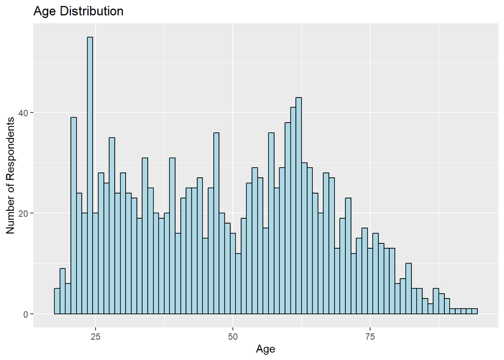

```r
#plotting the distribution of ages among the respondents
suppressWarnings(ggplot(respondent_data,aes(`Age`))+geom_histogram(
                        fill="lightblue",color="black",binwidth=1)+labs(
                                                title="Age Distribution",
                                                x="Age",
                                                y="Number of Respondents",
                                                alt="The distribution of
                                                respondents based on their
                                              ages"))
```

But how does the ideology correlate with these ages? Taking a look at the chart “Ideology by Age” one might note the presence of more conservative views the older the pool gets, with the responses of “conservative” and “very conservative” taking larger sections of the bars on the right side. Comparatively the ratios present in the left side with the younger respondents have larger portions of their bars dedicated to moderate views.

Considering that conservative views within the United States tend to be associated with the older generation preserving the past, it makes sense that the majority of the “very conservative” responses are on the side of the graph with the older respondents.

It looks as though there are the beginnings for a trend within the aforementioned “Ideology by Age” chart that show a correspondence between Age and Ideology with the older respondents being more conservative compared to the younger ones.

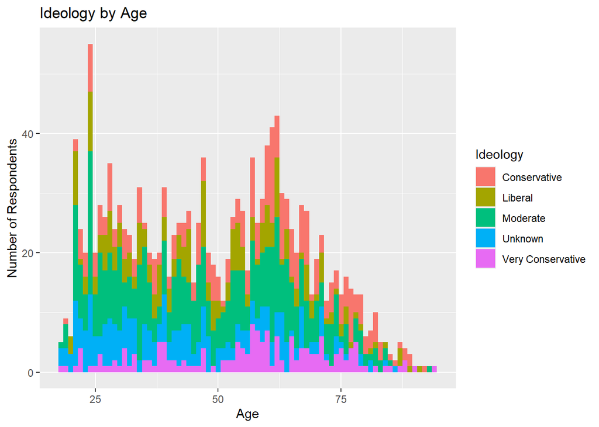

```r
#comparing the age to the ideology of the respondents
ggplot(respondent_data,aes(`Age`,fill=`Ideology`))+geom_histogram(
                                                binwidth = 1)+labs(
                                                title="Ideology by Age",
                                                x="Age",
                                                y="Number of Respondents",
                                                alt="Distribution of
                                                Ideology by age")
```

# Question 3: Does religion impact political ideology?

Different religions have different beliefs at their cores, things that make them what they are and that impact those who grow up with them. They have a way of teaching people what’s right and what’s wrong as most communities do, but how does religion impact political ideologies?

To understand this, it is important to first understand the breakdown of the political ideologies within the study, which I find myself using the “Ideological Distribution” Bar Chart to do. It allows me to see visually that of the 1500 respondents within this study, 314 of them identified as “Conservative”, 240 identified as “Liberal”, 515 identified as “Moderate”, 168 identified as “Very Conservative”, and 263 had unknown political ideologies. So, ~20% of the respondents identified as “Conservative”, 16% as “Liberal”, ~33% as “Moderate”, ~11% as “Very Conservative”, and ~18% were unknown responses, all shown in the “Ideological Distribution” chart.

```r
#getting a count of the different ideology types
respondent_data %>% count(`Ideology`)
```

| Ideology | n |
| --- | --- |
| Conservative | 314 |
| Liberal | 240 |
| Moderate | 515 |
| Unknown | 263 |
| Very Conservative | 168 |

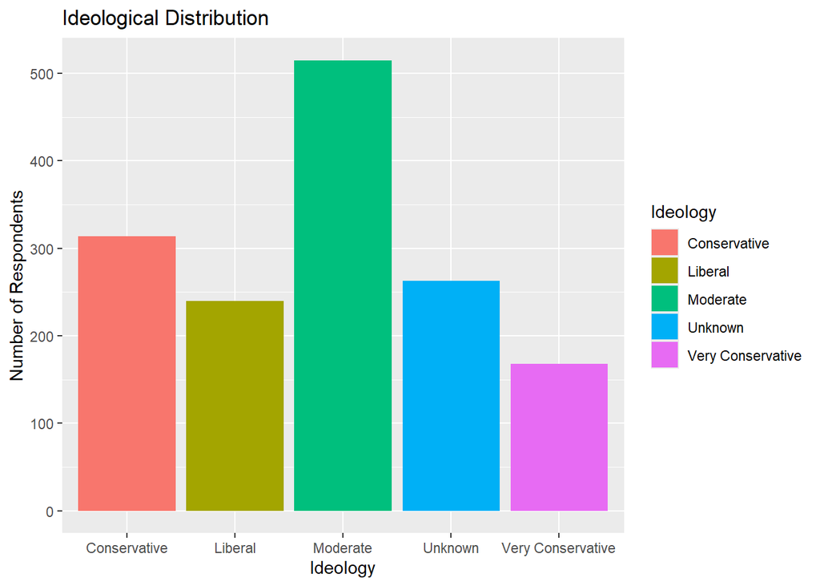

```r
#plotting the distribution of ideologies
ggplot(respondent_data,aes(`Ideology`,fill=`Ideology`))+geom_bar()+labs(title="Ideological Distribution",x="Ideology",y="Number of Respondents", alt="Distribution of different ideologies amongst respondents")
```

The distributions of religion among theses charts paint a very clear painting with of those who are 54 of those who are not religious being “Conservative” and 260 being religious, 98 “Liberal” respondents being not religious while 142 are, 145 “Moderate” respondents being not religious where 370 are, 24 “Very Conservative” respondents being not religious where 144 are, and 136 respondents with “Unknown” ideologies are not religious while 127 are.

The data shows a huge trend towards those who are conservative being religious, with only 17% of those who are not religious calling themselves “Conservative” while 83% were religious, the numbers for “Very Conservative” at 14% not religious and 86% religious reinforcing the idea. And aside from the 51% not religious and 49% religious split of the Unknowns, 51% not religious and 49% religious, the closest there is to a 50/50 split is with the “Liberal” ideology at 40% not religious, 60% religious, compared to the “Moderate” ideology’s 28% not religious, 72% religious.

The significant trend of Religious Respondents composing the majority of the “Conservative” and “Very Conservative” ideologies while Non-Religious respondents have closer percentages to the Religious respondents in the “Liberal” ideology, shows at least a correlation between religion and ideology supporting the idea that religion has an impact on one’s political ideologies.

```r
#getting the numbers for the counts of each ideology's religious vs
#non-religious respondents

conservative_respondents<-filter(respondent_data,
                                 `Ideology`=="Conservative")

conservative_respondents %>% count("Conservative Ideologies"=`Religious`)
```

| Conservative Ideologies | n |
| --- | --- |
| Not Religious | 54 |
| Religious | 260 |

```r
#plotting ideology v religion

liberal_respondents<-filter(respondent_data,`Ideology`=="Liberal")

liberal_respondents %>% count("Liberal Ideologies"=`Religious`)
```

| Liberal Ideologies | n |
| --- | --- |
| Not Religious | 98 |
| Religious | 142 |

```r
moderate_respondents<-filter(respondent_data,`Ideology`=="Moderate")

moderate_respondents %>% count("Moderate Ideologies"=`Religious`)
```

| Moderate Ideologies | n |
| --- | --- |
| Not Religious | 145 |
| Religious | 370 |

```r
vconservative_respondents<-filter(
  respondent_data,`Ideology`=="Very Conservative")

vconservative_respondents %>% count(
  "Very Conservative Ideologies"=`Religious`)
```

| Very Conservative Ideologies | n |
| --- | --- |
| Not Religious | 24 |
| Religious | 144 |

```r
unknown_respondents<-filter(respondent_data,`Ideology`=="Unknown")

unknown_respondents %>% count("Unknown Ideologies"=`Religious`)
```

| Unknown Ideologies | n |
| --- | --- |
| Not Religious | 136 |
| Religious | 127 |

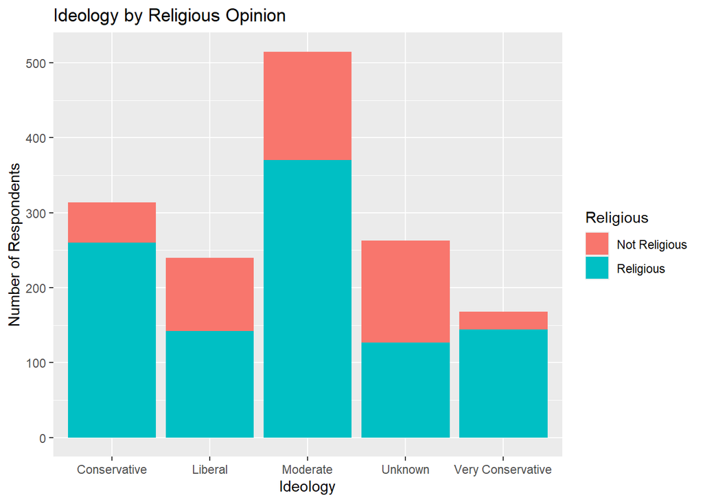

```r
#plotting ideology v religion

ggplot(respondent_data,aes(`Ideology`,
                                  fill=`Religious`))+geom_bar()+labs(
                                  title="Ideology by Religious Opinion",
                                  x="Ideology",
                                  y="Number of Respondents",
                                  alt="Distribution of
                                  Ideology based on whether one claims to
                                  be religious")
```

# In Conclusion

Who we are, what we believe, who we spend time with, they certainly do impact our lives, but to look at the building blocks and assume you can figure out the building isn’t quite right.

There were trends showing that conservative ideology seemed to correlate with both age and religion, but correlation is not necessarily causation.

To further enhance this project, I would say a more human element is necessary as quantatative data can prove trends, but to fully understand the impact one’s communities and connections has, one needs to actually hear the stories of those impacted and the ways it changed them.

# Bibliography

Herlihy, M. T., & Nelson, M. J. (2025). Judging Judicial Nominees. Political Research Quarterly, 0(0). https://doi.org/10.1177/10659129251350143

Nelson, Michael; Morrgan T. Herlihy, 2025, “Replication Data for: Judging Judicial Nominees”, https://doi.org/10.7910/DVN/WKKIPX, Harvard Dataverse, V1, UNF:6:Sd2qfsLuJhL0W7lldrLQsw== [fileUNF]